# Introdução à Ciência de Dados

Mestrado em Administração  
Aula 14

Prof. Washington Santos da Silva

IFMG - Campus Formiga

18 de junho de 2026

## Nesta Aula

**Módulo: Fundamentos de Inferência Estatística**

- Hoje, certamente, não vamos tentar cobrir todo o módulo de fundamentos de inferência estatística previsto no programa.
- O objetivo é tentar entender que:

> inferência estatística é o processo de **estimar uma quantidade desconhecida** associada à população usando uma amostra e **medir a incerteza dessa estimativa**.

## Ao final da aula

**Esperamos ser capazes de:**

1. Distinguir **parâmetro**, **estimador**, **estatística** e **estimativa**.
2. Explicar por que uma estimativa muda de amostra para amostra.
3. Interpretar **erro-padrão** e **intervalo de confiança**.
4. Construir um intervalo de confiança por **bootstrap**.
5. Executar um teste de hipótese por **permutação**.
6. Explicar por que a aleatorização fortalece a interpretação causal.

# Probabilidade, Simulação e Inferência Estatística

## Três perguntas diferentes

| Área | Pergunta típica | O que fazemos |
| --- | --- | --- |
| Probabilidade | Se **conhecemos** o processo gerador, o que pode acontecer? | Calculamos probabilidades, médias, quantis e riscos. |
| Simulação | Se repetirmos o processo muitas vezes, o que tende a ocorrer? | Geramos muitos cenários possíveis no computador. |
| Inferência estatística | Se observamos apenas uma amostra, o que podemos **aprender** sobre o processo gerador? | Estimamos parâmetros e medimos a incerteza. |

## Da probabilidade para a inferência

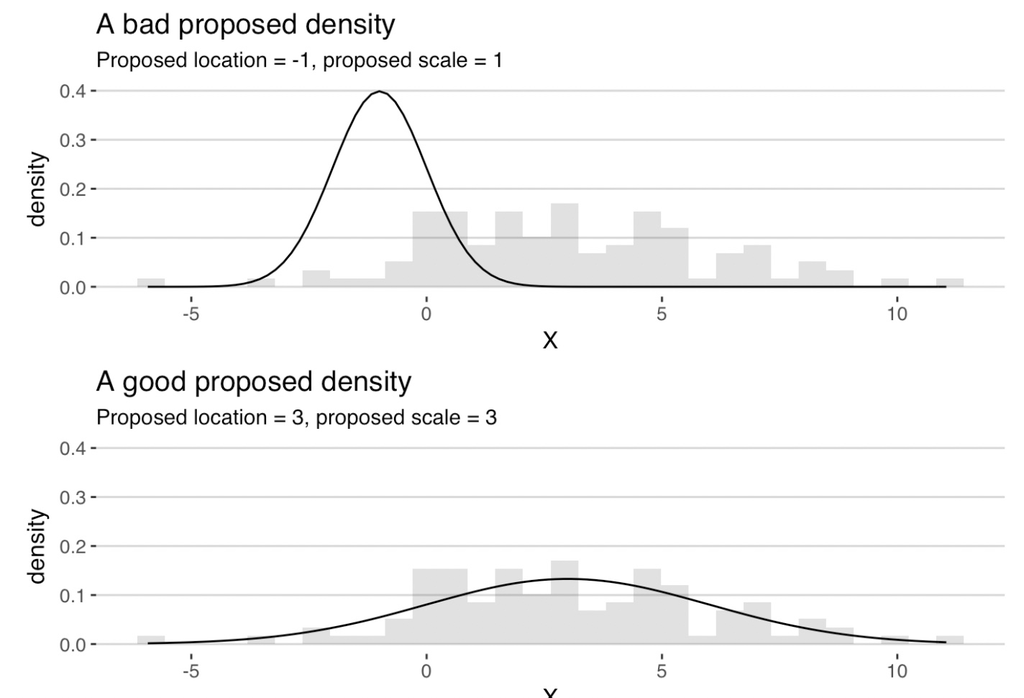

Do processo gerador aos dados; dos dados ao processo gerador

## Da probabilidade para a inferência

**Ideia-chave**

- Na probabilidade, **assumimos** uma distribuição de probabilidade e estudamos suas consequências.
- Na inferência estatística, observamos dados e tentamos **aprender** algo sobre a distribuição ou o processo que os gerou.

# Experimentos e Viés de Seleção

## O que é um experimento?

**Ideia básica**

Um experimento é uma forma planejada de comparar resultados entre unidades submetidas a diferentes condições, controlando ou balanceando, tanto quanto possível, outros fatores que poderiam afetar o resultado de interesse.

Em geral precisamos definir:

- **unidade experimental**: cliente, investidor, funcionário, equipe, loja, agência ou empresa;
- **tratamento**: mensagem, incentivo, enquadramento da informação, regra de decisão, versão de uma página ou desenho de uma escolha;
- **controle**: ausência da intervenção, versão atual ou condição usada como referência;
- **resposta**: variável observada depois da intervenção.

## O que é um experimento?

**Pergunta central**

A pergunta central é simples:

> a diferença observada entre os grupos pode ser atribuída de forma crível à intervenção, ou pode ser explicada pelo acaso ou por outros fatores?

## Comparações comuns

**Médias e proporções**

Muitos experimentos simples em Administração e Finanças podem ser resumidos por comparações como:

- diferença entre **médias**: tempo médio, produtividade média, retorno médio;
- diferença entre **proporções**: adesão, conversão, inadimplência, aprovação.

Para uma variável quantitativa:

$$\widehat{\Delta}_{\text{médias}}
= \bar{Y}_{\text{tratamento}}
-
\bar{Y}_{\text{controle}}$$

Para uma variável binária:

$$\widehat{\Delta}_{\text{proporções}}
= \widehat{p}_{\text{tratamento}} -
\widehat{p}_{\text{controle}}$$

A estatística pode ser simples. O desenho que gerou os dados é que determina se a comparação é convincente.

## Viés de seleção

**Descrição**

Há **viés de seleção** quando os grupos comparados já eram diferentes antes da intervenção.

Exemplos:

- usuários que escolhem uma nova funcionalidade podem ser mais engajados;
- clientes que aderem voluntariamente à educação financeira podem ser mais disciplinados;
- equipes escolhidas para receber um incentivo podem já ter desempenho superior;
- clientes que recebem oferta de crédito podem já ter sido selecionados por perfil de risco.

## Viés de seleção

**Descrição**

Nesses casos, a diferença posterior mistura duas coisas:

1. o possível efeito da intervenção;
2. **diferenças sistemáticas** prévias entre os grupos.

## Viés de seleção

**Problema**

- Quando há viés de seleção, comparar os resultados depois da intervenção pode ser enganoso.
- A diferença observada pode refletir não apenas o tratamento, mas também o fato de que os grupos já eram diferentes antes do tratamento.

## Atribuição aleatória ou aleatorização

**Ideia central**

**Atribuir aleatoriamente** significa usar um sorteio para decidir quais unidades serão alocadas a cada condição experimental, como tratamento ou controle.

O sorteio deve acontecer **antes** da intervenção.

Ele reduz o viés de seleção porque:

- a unidade experimental não escolhe o grupo em que entra;
- o pesquisador não escolhe quem recebe o tratamento;
- características como engajamento, disciplina, risco ou produtividade não determinam sistematicamente a alocação.

Assim, antes da intervenção, esperamos grupos semelhantes **em média**.

## Atribuição aleatória ou aleatorização

**Comparabilidade**

- A aleatorização não garante que os grupos serão idênticos em toda amostra.
- Ela assegura algo mais modesto e mais importante:

> diferenças pré-existentes não favorecem sistematicamente um grupo.
- Em uma amostra específica, ainda pode haver desequilíbrio por acaso.

## Atribuição aleatória ou aleatorização

**Comparação mais crível**

Em um experimento com atribuição aleatória bem executada, diferenças de médias ou proporções ganham uma interpretação causal defensável.

Para uma variável quantitativa:

$$\widehat{\Delta}
= \bar{Y}_{\text{tratamento}} - \bar{Y}_{\text{controle}}$$

Para uma variável binária:

$$\widehat{\Delta}
= \widehat{p}_{\text{tratamento}} - \widehat{p}_{\text{controle}}$$

A comparação continua sendo uma estimativa amostral. A diferença é que o desenho experimental torna mais crível interpretá-la como efeito causal da intervenção no contexto estudado.

## Análise de Experimentos

**Checklist mínimo**

Antes de analisar os dados de um experimento, precisamos saber:

- quem podia participar do experimento;
- como a alocação aos grupos foi feita;
- qual era exatamente o tratamento e qual era a condição de controle;
- quando a resposta foi medida;
- qual era a principal variável de resposta;
- se houve perda de participantes ou mudança no protocolo.

Sem esse registro, a comparação numérica pode parecer precisa, mas ser pouco confiável.

## Atribuição aleatória ou aleatorização

**O que a aleatorização não resolves**

Mesmo em experimentos, ainda precisamos avaliar:

- tamanho da amostra;
- execução correta da aleatorização;
- perda seletiva de participantes;
- interferência entre unidades;
- erro de mensuração;
- validade externa: para quem o resultado se aplica?

# Aplicação: teste A/B

## Aplicação: teste A/B

**Decisão gerencial**

Uma equipe de produto quer decidir se deve substituir a página atual de uma plataforma por uma versão redesenhada.

A métrica principal é o **tempo de permanência** na página, em minutos.

A pergunta substantiva é:

> a versão redesenhada aumenta o tempo médio de permanência dos usuários?

## Desenho do experimento A/B

**Descrição**

| Elemento | Definição no exemplo |
| --- | --- |
| Unidade experimental | Usuário elegível que acessa a página durante o experimento |
| Controle | Versão A: página atual |
| Tratamento | Versão B: página redesenhada |
| Atribuição | Sorteio automático no primeiro acesso do usuário |
| Resultado | Tempo de permanência na página, em minutos |
| Parâmetro de interesse | Diferença média: versão B menos versão A |

## Desenho do experimento A/B

**Por que isso é um experimento?**

- Como há atribuição aleatória, diferenças sistemáticas entre os grupos tendem a ser neutralizadas pelo desenho experimental.

## Desenho do experimento A/B

**O que os dados representam?**

- Os dados não comparam usuários que **escolheram** a versão A com usuários que **escolheram** a versão B.
- Cada usuário foi exposto a apenas uma versão, definida por sorteio.
- Para manter o exemplo simples, vamos assumir que:
  - todos os usuários sorteados tiveram o tempo medido;
  - a métrica foi calculada da mesma forma nos dois grupos;
  - não houve mudança simultânea em outra parte da plataforma;
  - um usuário não influenciou a experiência de outro.

## Dados do experimento

```r
# exibe algumas observações de cada versão
dados_ab |>
  slice(c(1:5, 16:20, 21:25, 36:40))
```

```
# A tibble: 20 × 2
   versao          tempo_min
   <fct>               <dbl>
 1 A - atual             3.2
 2 A - atual             4.1
 3 A - atual             2.8
 4 A - atual             3.9
 5 A - atual             3.5
 6 A - atual             2.7
 7 A - atual             4.5
 8 A - atual             3.4
 9 A - atual             2.5
10 A - atual             3.9
11 B - redesenhada       3.8
12 B - redesenhada       4.2
13 B - redesenhada       3.3
14 B - redesenhada       4.6
15 B - redesenhada       3.7
16 B - redesenhada       4.5
17 B - redesenhada       3.2
18 B - redesenhada       4.8
19 B - redesenhada       3.7
20 B - redesenhada       4.2
```

## Resumo por grupo

```r
# calcula o resumo descritivo por versão da página
resumo_ab <- dados_ab |>
  group_by(versao) |>
  summarise(
    n = n(),
    media_tempo = mean(tempo_min),
    desvio_padrao = sd(tempo_min),
    erro_padrao_media = desvio_padrao / sqrt(n)
  )

# exibe o resumo que será usado na interpretação
resumo_ab
```

```
# A tibble: 2 × 5
  versao              n media_tempo desvio_padrao erro_padrao_media
  <fct>           <int>       <dbl>         <dbl>             <dbl>
1 A - atual          20        3.5          0.598             0.134
2 B - redesenhada    20        3.98         0.473             0.106
```

## Pergunta substantiva

**Efeito da versão B**

Queremos estimar:

$$\Delta = \mu_B - \mu_A$$

onde:

- $\mu_A$ é o tempo médio que seria observado sob a versão atual;
- $\mu_B$ é o tempo médio que seria observado sob a versão redesenhada;
- $\Delta$ é o efeito médio da versão B em relação à versão A.

A estimativa amostral será:

$$\widehat{\Delta} = \bar{Y}_B - \bar{Y}_A$$

# Conceitos Básicos

## Parâmetro, estimador e estimativa

**Descrição**

| Conceito | O que é | No experimento A/B |
| --- | --- | --- |
| Parâmetro | Quantidade desconhecida do processo/população | $\Delta = \mu_B - \mu_A$ |
| Estimador | Regra ou fórmula aplicada aos dados | $\widehat{\Delta} = \bar{Y}_B - \bar{Y}_A$ |
| Estimativa | Valor numérico obtido na amostra | diferença média observada |
| Estatística | Qualquer função dos dados amostrais | média, mediana, diferença, quantil |

## Estatística e estimador

**Esclarecendo**

- Todo **estimador é uma estatística**, uma função dos dados.
- A diferença está no propósito: chamamos de estimador a estatística escolhida para **estimar um parâmetro**.
- Nesse caso, $\bar{Y}_B - \bar{Y}_A$ é a estatística que serve de estimador de $\Delta$.

## Estimador e Estimativa

**Descrição**

#### Estimador

- É uma variável aleatória.
- Depende da amostra sorteada.
- Tem uma distribuição de probabilidade.
- Essa distribuição é chamada de **distribuição amostral**.

#### Estimativa

- É um número.
- Foi calculada com a amostra observada.
- Não mostra, sozinha, quão incerta é a conclusão.
- Precisa vir acompanhada de alguma medida de incerteza.

# Estimação Pontual

## Estimação Pontual

**Descrição**

Uma estimativa pontual resume os dados em um único número.

No experimento A/B, a estimativa pontual do efeito da versão B é a diferença entre as médias observadas:

$$\widehat{\Delta} = \bar{Y}_B - \bar{Y}_A$$

Esse número é útil, mas ainda não é inferência completa. **Por que?**

## Estimativa do efeito médio

```r
# organiza as médias e a diferença B menos A
# em uma tibble
tibble(
  media_a = media_a_observada,
  media_b = media_b_observada,
  diferenca_b_menos_a = diferenca_ab_observada
)
```

```
# A tibble: 1 × 3
  media_a media_b diferenca_b_menos_a
    <dbl>   <dbl>               <dbl>
1     3.5    3.98               0.485
```

## Limitação da estimativa pontual

**Importante**

- A diferença média observada informa o sinal encontrado na amostra.
- Mas ela não responde:
  - quanto essa diferença mudaria se repetíssemos o experimento;
  - qual faixa de valores é compatível com os dados;
  - se a diferença é grande em relação ao ruído/variabilidade amostral;
  - se a diferença é relevante para a decisão gerencial.
- Para isso precisamos estudar a **incerteza da estimativa**.

## Método de estimação

**Exemplo: Método da máxima verossimilhança**

- O método da **máxima verossimilhança** é um método geral para construir estimadores.
- A ideia é encontrar os parâmetros que tornam os dados observados mais plausíveis dentro de um modelo probabilístico assumido.

$$\hat{\theta}_{MV} =
\operatorname*{arg\,max}_{\theta} L(\theta \mid x_1, \ldots, x_n)$$

ou, de forma equivalente, maximizar a log-verossimilhança:

$$\ell(\theta) = \log L(\theta)$$

## Método da Máxima Verossimilhança

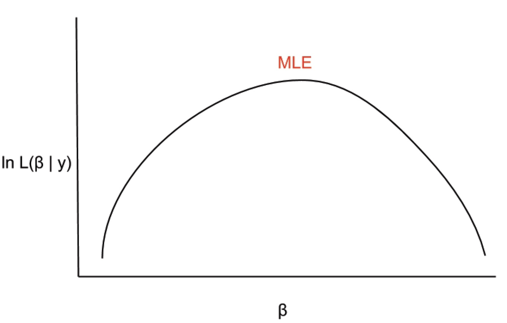

Curva da função de log-verossimilhança

## Método de estimação

**Importante**

- O ponto é entender que diferentes métodos de estimação produzem estimadores;
- E que esses estimadores precisam ser avaliados analisando suas propriedades.

## Algumas Propriedades de estimadores

**Nota**

| Propriedade | Pergunta que ela responde | Intuição |
| --- | --- | --- |
| **Viés** | Em média, o estimador acerta o parâmetro? | Erro sistemático |
| **Variância** | O estimador varia muito entre amostras? | Precisão |
| **Eficiência** | Há outro estimador com menor variância? | Melhor uso da informação |
| **Consistência** | Com amostras maiores, o estimador se aproxima do parâmetro? | Comportamento em grandes amostras |

## O que fica para Econometria?

**Continuidade natural**

Em econometria, essas ideias reaparecem em modelos como:

- regressão linear por mínimos quadrados;
- modelos com variáveis instrumentais;
- modelos usados para inferência causal;
- modelos não lineares, como logit e probit.

# Distribuição Amostral

## Estimador é variável aleatória

**Ideia central**

Imagine que pudéssemos repetir o experimento muitas vezes:

1. sortear novos usuários;
2. alocar usuários entre A e B;
3. calcular uma nova diferença média;
4. repetir isso centenas ou milhares de vezes.

As diferenças médias não seriam idênticas.

A distribuição dessas diferenças é a **distribuição amostral** do estimador.

## Visualizando a distribuição amostral

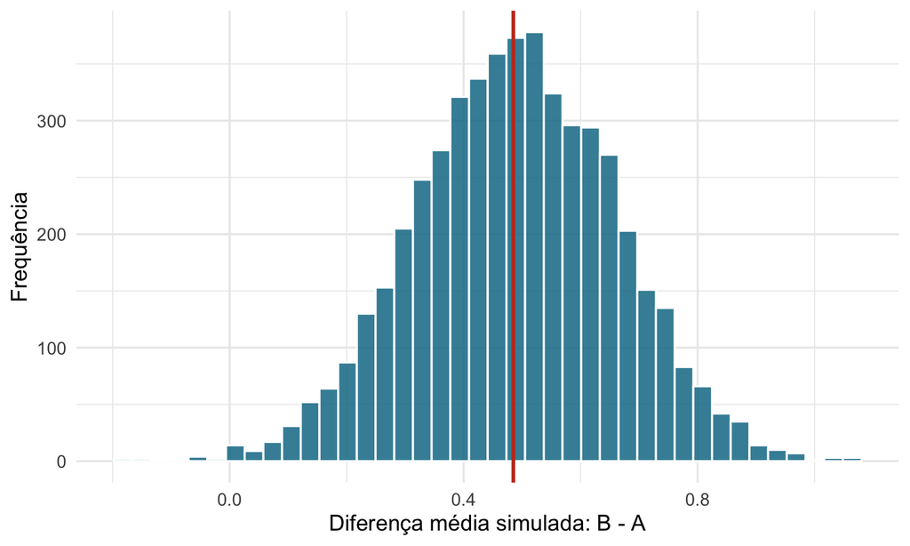

Distribuição amostral simulada da diferença de médias.

## Erro-padrão

**Definição**

- O **erro-padrão** de um estimador é o desvio-padrão da distribuição amostral deste estimador.
- Ele mede a incerteza da **estimativa do coeficiente**.
- Para a diferença entre duas médias independentes:

$$EP(\bar{Y}_B - \bar{Y}_A) =
\sqrt{\frac{\sigma_B^2}{n_B} + \frac{\sigma_A^2}{n_A}}$$

- Como $\sigma_A$ e $\sigma_B$ geralmente são desconhecidos, usamos os desvios-padrão amostrais.

# O pacote infer

## O pacote `infer`

**Descrição**

- O pacote `infer` expressa a inferência por simulação como um *pipeline* de verbos encadeados pelo operador pipe (`|>` ou `%>%`) cada um correspondendo a um passo do raciocínio.

## O pacote `infer`

**Funções/Verbos**

| Função/verbo | O que faz | Argumento-chave |
| --- | --- | --- |
| `specify()` | define resposta e explicativa | `resposta ~ explicativa` |
| `hypothesize()` | fixa a hipótese nula (só em testes) | `null = "independence"` |
| `generate()` | gera réplicas simuladas | `type = "bootstrap"` / `"permute"` |
| `calculate()` | calcula a estatística em cada amostra | `stat = "diff in means"`, `order =` |
| `visualize()` | desenha a distribuição simulada | — |

## O pacote `infer`

**Funções auxiliares**

- `get_confidence_interval()` resume a distribuição bootstrap em um intervalo;
- `get_p_value()` localiza a estatística observada na distribuição nula;

## O pacote `infer`

**Procedimentos para obter estimativas por intervalo e testes de hipóteses**

| Etapa | Intervalo (bootstrap) | Teste (permutação) |
| --- | --- | --- |
| `specify()` | `tempo_min ~ versao` | `tempo_min ~ versao` |
| `hypothesize()` | — | `null = "independence"` |
| `generate()` | `type = "bootstrap"` | `type = "permute"` |
| `calculate()` | `stat = "diff in means"` | `stat = "diff in means"` |
| resumo | `get_confidence_interval()` | `get_p_value()` |

## Intervalo de confiança via bootstrap

**Três tipos de intervalo de confiança**

A partir da distribuição bootstrap, `get_confidence_interval(type = ...)` oferece:

| `type` | Como constrói o intervalo |
| --- | --- |
| `"percentile"` | quantis 2,5% e 97,5% da distribuição bootstrap |
| `"se"` | estimativa $\pm\, 1{,}96 \cdot \text{EP}_{\text{boot}}$ (95%); supõe simetria aproximada |
| `"bias-corrected"` | ajusta os percentis usando a posição da estimativa original na distribuição bootstrap; corrige viés de localização |

## Intervalo de confiança via bootstrap

**Tipos de interesse para esta aula**

- Nesta aula, usaremos o `"percentile"` porque é o método mais direto para conectar reamostragem e interpretação.
- O `"se"` e o `"bias-corrected"` existem, mas exigem discutir simetria, viés da distribuição bootstrap e escolha do ponto estimado.
- Se a distribuição bootstrap for muito assimétrica ou a amostra for pequena, o intervalo deve ser interpretado com cautela; trocar o `type` não resolve automaticamente o problema.

# Bootstrap

## O problema e a ideia do bootstrap

**De uma amostra, muitas amostras**

- Precisamos da **distribuição amostral** de um estimador para fazer inferência.
- O problema: temos **uma única amostra** e não podemos voltar à população para coletar outras.
- A ideia do bootstrap é tratar a amostra observada como se fosse a população e **sortear novas amostras dela, com reposição**.
- Cada reamostra tem o mesmo tamanho da amostra original; a reposição é o que faz uma observação aparecer mais de uma vez, ou nenhuma.

## Bootstrap

**O princípio *plug-in***

- A amostra é a melhor informação que temos sobre a população. Reamostrar com reposição **imita o ato de amostrar da população**
- A variação entre as reamostras aproxima a variação que haveria entre amostras reais.
- No lugar da distribuição populacional, desconhecida, usamos a distribuição dos próprios dados — quanto maior a amostra, melhor a aproximação.

## Bootstrap

**Procedimento de reamostragem**

O bootstrap usa a própria amostra observada como aproximação da população.

A lógica é:

1. sorteamos observações da amostra original **com reposição**;
2. calculamos a estatística de interesse;
3. repetimos muitas vezes;
4. usamos a distribuição das estatísticas reamostradas como uma aproximação da distribuição amostral.
5. Obtemos estimativas de intervalos de confiança dos parâmetros.

## Bootstrap paramétrico e não paramétrico

|  | Não paramétrico | Paramétrico |
| --- | --- | --- |
| Como gera amostras | reamostra os **dados** com reposição | simula de uma **distribuição** ajustada |
| Suposição | nenhuma sobre a forma da distribuição | assume uma família (ex.: Normal) |
| Exemplo nesta aula | o bootstrap do `infer` | a simulação normal da distribuição amostral |

## Bootstrap no experimento A/B

**A estatística de interesse**

No experimento A/B, a estatística que reamostramos por bootstrap é a diferença de médias:

$$\widehat{\Delta} = \bar{Y}_B - \bar{Y}_A$$

A seguir, aplicamos a ela o pipeline do `infer` para obter o intervalo de confiança.

## Bootstrap da diferença média

```r
# fixa a semente para reproduzir as reamostragens
set.seed(2026)

# gera a distribuição bootstrap da diferença de médias
boot_ab <- dados_ab |>
  specify(tempo_min ~ versao) |>
  generate(reps = n_reps, type = "bootstrap") |>
  calculate(stat = "diff in means", order = ordem_ab)

# calcula o intervalo de confiança pelo método percentil
ic_boot_ab <- boot_ab |>
  get_confidence_interval(level = 0.95, type = "percentile")

# reúne a estimativa original, o erro-padrão e os limites do intervalo
tibble(
  estimativa_original = diferenca_ab_observada,
  erro_padrao_boot = sd(boot_ab$stat),
  limite_inferior = ic_boot_ab$lower_ci,
  limite_superior = ic_boot_ab$upper_ci
)
```

```
# A tibble: 1 × 4
  estimativa_original erro_padrao_boot limite_inferior limite_superior
                <dbl>            <dbl>           <dbl>           <dbl>
1               0.485            0.166           0.145           0.810
```

## Visualização do bootstrap

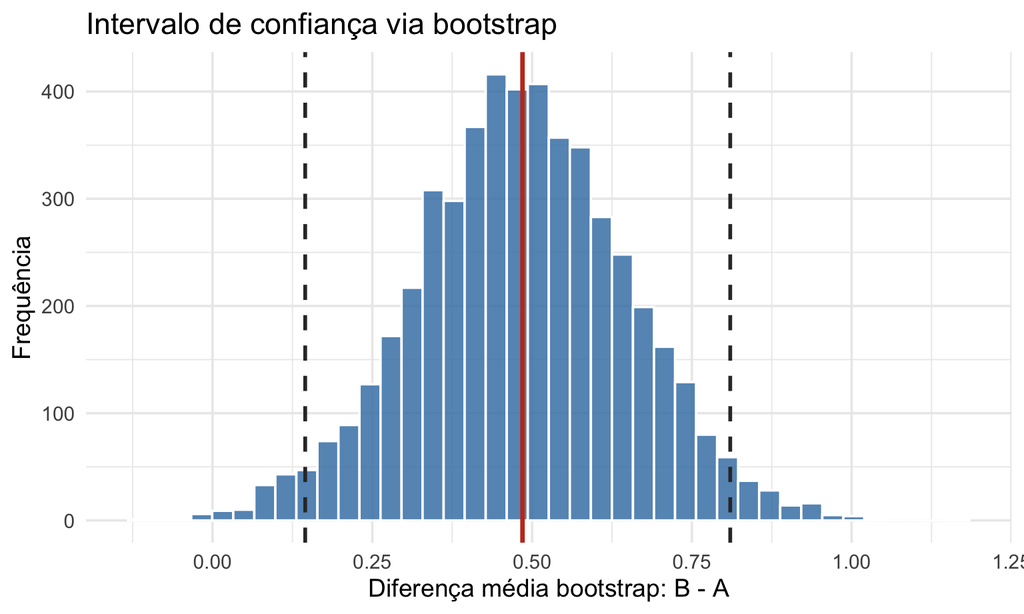

## Como interpretar o intervalo?

**Interpretação prática**

O intervalo de confiança informa uma faixa de valores plausíveis para o efeito médio da versão B, considerando a variabilidade amostral capturada pelo procedimento.

Uma interpretação cuidadosa é:

> neste experimento, a versão B aumentou o tempo médio de permanência; o intervalo bootstrap mostra a incerteza associada a essa estimativa.

A interpretação causal depende do desenho experimental, não apenas do intervalo.

## Limitações do bootstrap

**Descrição**

- O bootstrap ajuda a medir incerteza amostral.
- Ele não corrige:
  - problemas de aleatorização;
  - perda seletiva de participantes;
  - erro de mensuração;
  - interferência entre unidades;
  - amostra que não representa a população de interesse;
  - ausência de identificação causal em dados observacionais.
- Se a amostra não representam bem o processo ou população de interesse, reamostrar esses dados também carrega o problema.

# Teste de Hipótese por Permutação

## Da estimação ao teste

**Pergunta**

Agora queremos testar:

> a versão B realmente altera o tempo médio de permanência?

Primeiro calculamos a diferença observada.

Depois perguntamos:

> essa diferença é grande em relação ao que esperaríamos se a versão da página não tivesse nenhum efeito?

## Anatomia de um teste de permutação

**Quatro passos**

1. **Estatística de teste** — escolher uma medida do efeito; nesse caso, a diferença de médias $\bar{Y}_B - \bar{Y}_A$.
2. **Distribuição nula** — sob $H_0$ os rótulos são permutáveis: embaralhá-los muitas vezes e recalcular a estatística gera os valores que surgiriam **por acaso**.
3. **Localizar a estimativa observada** — situar a estatística observada dentro dessa distribuição nula.
4. **Valor-p** — probabilidade frequentista de obter um resultado **tão ou mais extremo** quanto o observado, nas duas direções.

## Anatomia de um teste de permutação

**A pergunta, em uma frase**

*Entre os resultados que o puro embaralhamento dos rótulos produz, quão incomum é o que observamos?*

Quanto mais raro, mais os dados contrariam a hipótese de efeito nulo.

## Diferença observada

```r
# relembra o resumo descritivo por versão
resumo_ab
```

```
# A tibble: 2 × 5
  versao              n media_tempo desvio_padrao erro_padrao_media
  <fct>           <int>       <dbl>         <dbl>             <dbl>
1 A - atual          20        3.5          0.598             0.134
2 B - redesenhada    20        3.98         0.473             0.106
```

```r
# exibe a estatística observada que será comparada com a hipótese nula
obs_ab |>
  rename(diferenca_observada_b_menos_a = stat)
```

```
Response: tempo_min (numeric)
Explanatory: versao (factor)
# A tibble: 1 × 1
  diferenca_observada_b_menos_a
                          <dbl>
1                         0.485
```

## Hipótese nula

**Ideia do teste por permutação**

- Hipótese nula (efeito nulo):

$$H_0: \text{a versão da página não altera o tempo médio de permanência}$$

- Se $H_0$ for verdadeira, a versão da página não está associada sistematicamente ao tempo de permanência. O rótulo “A” ou “B” vira uma **etiqueta permutável**, e diferenças positivas ou negativas podem surgir apenas pelo acaso do sorteio.
- Por isso podemos **reembaralhar os rótulos** e recalcular a diferença de médias: cada embaralhamento é uma das alocações que o sorteio poderia ter gerado sob a hipótese de ausência de diferença média.

## A aleatorização justifica o teste

**O elo entre desenho e inferência**

- No experimento, os grupos A e B foram formados por **aleatorização**. O teste por permutação **repete esse mesmo sorteio** milhares de vezes no computador, agora supondo que a versão não tem efeito.
- A distribuição de referência sob $H_0$ é gerada pelo **próprio mecanismo de aleatorização** que criou os grupos, não por uma fórmula teórica.
- Não é preciso supor normalidade nem amostra grande.
- A validade do teste vem do **desenho** (a aleatorização), não de hipóteses sobre a distribuição dos dados.

> Em um experimento aleatorizado, embaralhar os rótulos é reencenar o sorteio sob a hipótese de efeito nulo. O teste por permutação é a tradução quase literal da pergunta causal.

## Bootstrap e Teste por Permutação

**Diferencás**

|  | Bootstrap | Permutação |
| --- | --- | --- |
| Objetivo | medir incerteza / intervalo | testar uma hipótese nula |
| Reamostragem | **com** reposição, mantém os rótulos | **sem** reposição, embaralha os rótulos |
| Distribuição centrada em | estimativa observada | valor nulo (zero) |
| Resultado | intervalo de confiança / erro-padrão | valor-p |
| Pressuposto-chave | a amostra representa a população | permutabilidade dos rótulos sob $H_0$ |

## Teste por permutação em R

```r
# fixa a semente para reproduzir as permutações
set.seed(2026)

# gera a distribuição nula permutando a relação entre tempo e versão
dist_nula_ab <- dados_ab |>
  specify(tempo_min ~ versao) |>
  hypothesize(null = "independence") |>
  generate(reps = n_reps, type = "permute") |>
  calculate(stat = "diff in means", order = ordem_ab)

# calcula o valor-p bilateral a partir da distribuição nula
dist_nula_ab |>
  get_p_value(obs_stat = obs_ab, direction = "two-sided")
```

```
# A tibble: 1 × 1
  p_value
    <dbl>
1  0.0072
```

## Distribuição sob a hipótese nula

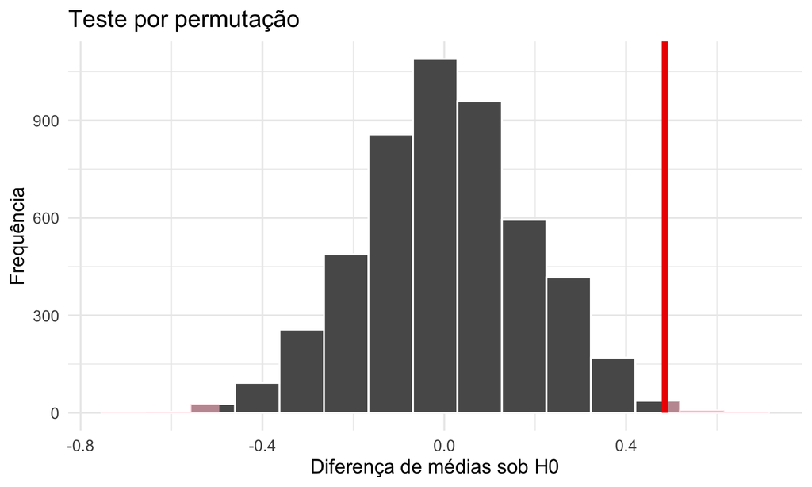

## Como interpretar o valor-p?

**Interpretação**

O valor-p responde:

> se a hipótese nula fosse verdadeira, qual a probabilidade de obter diferenças tão ou mais extremas que a observada, em qualquer direção?

O valor-p **não** responde:

- a probabilidade de a hipótese nula ser verdadeira;
- a probabilidade de a hipótese alternativa ser verdadeira;
- se o efeito é economicamente importante;
- se o experimento generaliza para todos os usuários futuros.

## Teste por permutação e teste t

**Relação com o teste t clássico**

- O teste por permutação é o análogo **não paramétrico** do teste $t$ de duas amostras:
- Neste exemplo, o resultado é praticamente o mesmo,(o `Pr(>|t|)` que aparece na regressão, adiante), mas sem supor normalidade.

## Muito importante!

**Significância estatística não é significância prática**

- Uma diferença pode ser estatisticamente detectável e economicamente pequena.
- Também pode ser economicamente relevante e estatisticamente incerta, especialmente com amostras pequenas.
- Em pesquisa empírica aplicada, precisamos interpretar conjuntamente:
  - tamanho do efeito;
  - incerteza da estimativa;
  - desenho de pesquisa;
  - plausibilidade substantiva;
  - custo de implementação.

# Sobre o Experimento A/B

## Síntese

**O que aprendemos com o experimento?**

O experimento A/B combina duas ideias:

- **desenho de pesquisa**: a alocação aleatória reduz viés de seleção em média;
- **inferência estatística**: bootstrap e permutação medem a incerteza da estimativa.

No exemplo, se a aleatorização foi bem executada, a diferença média entre B e A pode ser interpretada como **efeito causal** da versão redesenhada sobre o tempo de permanência, no contexto do experimento.

## Síntese

**O que aprendemos com o experimento?**

Ainda assim, a conclusão depende de cautelas:

- a aleatorização foi realmente executada?
- houve perda seletiva de usuários?
- a métrica foi medida da mesma forma nos dois grupos?
- o experimento durou tempo suficiente?
- há efeitos colaterais sobre outras métricas relevantes?
- a amostra representa os usuários para os quais queremos decidir?

# Ponte para Econometria

## Ponte para Econometria

**A mesma lógica aparece em regressão**

| Nesta aula | Em regressão |
| --- | --- |
| Parâmetro desconhecido | Coeficiente populacional, como $\beta_1$ |
| Estimador | Fórmula que estima o coeficiente |
| Estimativa | Coeficiente estimado, como $\hat{\beta}_1 = 0{,}42$ |
| Erro-padrão | Incerteza do coeficiente estimado |
| Intervalo de confiança | Faixa plausível para o coeficiente |
| Teste de hipótese | Teste sobre $\beta_1 = 0$ ou outro valor |
| Desenho de pesquisa | Condições para interpretação causal |

## O experimento A/B como regressão

```r
# estima uma regressão com a versão da página como explicativa
modelo_ab <- lm(tempo_min ~ versao, data = dados_ab)

# exibe coeficientes, erro-padrões, estatísticas t e valores-p
summary(modelo_ab)$coefficients
```

```
                      Estimate Std. Error t value
(Intercept)              3.500    0.12056 29.0323
versaoB - redesenhada    0.485    0.17049  2.8447
                                               Pr(>|t|)
(Intercept)           0.0000000000000000000000000015163
versaoB - redesenhada 0.0071214321036858043226236425483
```

## Como ler esse resultado?

| Coluna | Pergunta |
| --- | --- |
| Estimate | Qual foi a estimativa pontual do coeficiente? |
| Std. Error | Quão incerta é essa estimativa? |
| t value | A estimativa é grande em relação ao erro-padrão? |
| Pr(>\|t\|) | Quão extrema seria essa estatística sob a hipótese nula? |

## Como ler esse resultado?

**Std. Error: por que coincide com a fórmula?**

- O Std. Error de `versaoB - redesenhada` praticamente coincide com o erro-padrão obtido pela fórmula e pelo bootstrap (≈ 0,17), porque o desenho é **balanceado** ($n_A = n_B$): nesse caso, a fórmula com variâncias separadas e o erro-padrão agrupado do `lm()` produzem o mesmo valor.
- Em geral, eles **diferem**: o `lm()` assume, por padrão, variâncias iguais nos dois grupos (homocedasticidade). Relaxar essa hipótese, com erros-padrão robustos, é tema de Econometria.

# Síntese

## Síntese

**Cinco ideias**

1. Uma estimativa pontual é apenas o começo da inferência.
2. Estimadores são variáveis aleatórias; por isso precisamos conhecier sua distribuição de probabilidade (distribuição amostral).
3. Erro-padrão mede a incerteza da estimativa, é o desvio-padrão da distribuição amostral de um estimador.
4. Bootstrap e teste por permutação são técnicas modernas de inferência estatística que usam simulação ao invés de resultados analíticos.
5. Aleatorização é o que permite transformar diferença estatística em evidência causal mais crível.

# Exercícios

## Dados dos exercícios

**Experimento: incentivos e produtividade**

- Nos exercícios, usaremos um segundo experimento didático.
- Uma empresa quer avaliar qual política gera maior produtividade semanal:
  - bônus monetário por meta atingida;
  - reconhecimento não monetário, como destaque público e certificado.
- Funcionários elegíveis, em funções comparáveis, foram sorteados para uma das duas políticas.

## Desenho do experimento

**Descrição**

| Elemento | Definição no exemplo |
| --- | --- |
| Unidade experimental | Funcionário elegível |
| Grupo A | Incentivo monetário |
| Grupo B | Incentivo não monetário |
| Atribuição | Sorteio antes do início da semana de avaliação |
| Resultado | Unidades produzidas na semana após o incentivo |
| Parâmetro de interesse | Diferença média: monetário menos não monetário |

## Desenho do experimento

**Cuidado**

- Se os funcionários mais produtivos tivessem escolhido o incentivo monetário, a comparação teria **viés de seleção**.
- O sorteio (atribuição aleatória) é o que torna a comparação entre médias uma evidência mais crível sobre o efeito relativo dos incentivos neste contexto.

## Dados do experimento

```r
# calcula o resumo descritivo por tipo de incentivo
dados_incentivos |>
  group_by(grupo) |>
  summarise(
    n = n(),
    media_produtividade = mean(produtividade),
    desvio_padrao = sd(produtividade)
  )
```

```
# A tibble: 2 × 4
  grupo                       n media_produtividade desvio_padrao
  <fct>                   <int>               <dbl>         <dbl>
1 Incentivo monetário        20                51.9          3.81
2 Incentivo não monetário    20                49            3.28
```

## Exercício 1

**Bootstrap**

Use `dados_incentivos` para estimar por bootstrap um intervalo de confiança d e 95% para a diferença média de produtividade:

$$\Delta = \mu_{\text{monetário}} - \mu_{\text{não monetário}}$$

Passos:

1. use `specify()` para declarar a relação entre produtividade e grupo;
2. use `generate(type = "bootstrap")`;
3. use `calculate(stat = "diff in means", order = ordem_incentivos)`;
4. use `get_confidence_interval(level = 0.95)`;
5. interprete o resultado em uma frase.

## Exercício 2

**Teste por permutação**

Use `dados_incentivos` para testar, por permutação, se o tipo de incentivo altera a produtividade média.

Use a sequência:

`specify()` → `hypothesize()` → `generate()` → `calculate()` → `get_p_value()`.

Interprete:

- a diferença observada;
- o valor-p simulado;
- o que o teste permite concluir;
- que condição do desenho experimental sustenta a leitura causal.

## Exercício 3

**Ponte para regressão**

Estime a regressão:

$$\text{tempo}_i = \beta_0 + \beta_1 \, \text{VersãoB}_i + u_i$$

usando `dados_ab`.

Depois responda:

1. qual é a estimativa de $\beta_1$?
2. como ela se relaciona com $\bar{Y}_B - \bar{Y}_A$?
3. qual é o erro-padrão dessa estimativa?
4. por que, neste caso, o coeficiente pode receber interpretação causal?

## Referências

COUCH, S. P. *et al.* [infer: An R package for tidyverse-friendly statistical inference](https://infer.tidymodels.org/). **Journal of Open Source Software**, v. 6, n. 65, p. 3661, 2021.

DEVORE, J. L. **Probabilidade e Estatística para Engenharia e Ciências**. São Paulo: Thomson, 2006.

ISMAY, C.; KIM, A. Y.; VALDIVIA, A. **[Statistical Inference via Data Science: A ModernDive into R and the Tidyverse](https://moderndive.com/v2/)**. 2. ed. Boca Raton: Chapman; Hall/CRC, 2024.

TIMBERS, T.; CAMPBELL, T.; LEE, M. **[Data Science: A First Introduction](https://datasciencebook.ca)**. Boca Raton: Chapman; Hall/CRC, 2024.